http://rbyexamples.blogspot.com/

## Linear regression

Let’s try regression on the auto dataset:

```r
library(leaps)
auto<- read.csv('../LinearRegression/data/auto.csv')
#attach(auto)
try(regfit.full <- regsubsets(price~., auto), silent = FALSE)
```

```
## Reordering variables and trying again:
```

It doesn’t work because by default, exhaustive search is performed. This requires lots of permutations, so you have to set really.big=TRUE if you want this.

But let’s just make things simpler by carving out a subset of variables:

```r
autosmall <- auto[,c(2,3,5,6,7,8,9,10,11)]
regfit.full <- regsubsets(price ~ . , autosmall) # the . indicates we want all variables to be considered.
summary(regfit.full)
```

```
## Subset selection object
## Call: regsubsets.formula(price ~ ., autosmall)
## 8 Variables  (and intercept)
##              Forced in Forced out
## mpg              FALSE      FALSE
## headroom         FALSE      FALSE
## trunk            FALSE      FALSE
## weight           FALSE      FALSE
## length           FALSE      FALSE
## turn             FALSE      FALSE
## displacement     FALSE      FALSE
## gear_ratio       FALSE      FALSE
## 1 subsets of each size up to 8
## Selection Algorithm: exhaustive
##          mpg headroom trunk weight length turn displacement gear_ratio
## 1  ( 1 ) " " " "      " "   "*"    " "    " "  " "          " "
## 2  ( 1 ) " " " "      " "   "*"    " "    "*"  " "          " "
## 3  ( 1 ) " " "*"      " "   "*"    " "    "*"  " "          " "
## 4  ( 1 ) " " " "      " "   "*"    "*"    "*"  " "          "*"
## 5  ( 1 ) " " "*"      " "   "*"    " "    "*"  "*"          "*"
## 6  ( 1 ) " " "*"      " "   "*"    "*"    "*"  "*"          "*"
## 7  ( 1 ) "*" "*"      " "   "*"    "*"    "*"  "*"          "*"
## 8  ( 1 ) "*" "*"      "*"   "*"    "*"    "*"  "*"          "*"
```

```r
regfit.fwd <- regsubsets(price~., autosmall, method="forward") # forward stepwise selection
regfit.bwd <- regsubsets(price~., autosmall, method="backward") # backward stepwise selection
coef(regfit.fwd,3) # gives the coefficients for regfit.fwd for the optimal 3-variable model
```

```
##  (Intercept)     headroom       weight         turn
## 10406.568615  -638.117661     4.228077  -380.789181
```

Recall that we actually need to split our dataset into a training set and test set. This is how we can do it:

```r
set.seed(1)
train <- sample(c(TRUE, FALSE),nrow(autosmall),rep=TRUE)
# if we wanted 75% of observations to be in training set, we can do the below:
# train <- sample(c(TRUE, FALSE),nrow(autosmall),rep=TRUE, prob = c(0.75, 0.25))
test <- (!train)

# another way of allocating the training/test sets:
# train <- sample(1:nrow(autosmall),  nrow(autosmall)/2)
# test <- (-train)
# autosmall.test <- autosmall[test]
# (notice that test contains all negative numbers, so all "train" observations are excluded)
```

To keep things simple, we didn’t do cross validation (as well as regularization). Here’s how to do cross-validation:

```r
regfit.full <- regsubsets(price~., autosmall[train,])
reg.summary <- summary(regfit.full) # for convenience
names(reg.summary)
```

```
## [1] "which"  "rsq"    "rss"    "adjr2"  "cp"     "bic"    "outmat" "obj"
```

For model selection, it’ll be useful to plot how RSS (and other measures such as adjusted R-sq) varies with number of variables:

```r
par(mfrow = c(1,2)) # sets a 1 row by 2 column plot
plot(reg.summary$rss,xlab="# of Var", ylab="RSS", type="l")
(m1 <- which.min(reg.summary$rss))
```

```
## [1] 8
```

```r
points(m1,reg.summary$rss[m1], col="red",cex=2,pch=20)
# cex refers to the dot thickness

plot(reg.summary$adjr2,xlab="# of Var", ylab="Adj R2", type="l")
(m1 <- which.max(reg.summary$adjr2))
```

```
## [1] 8
```

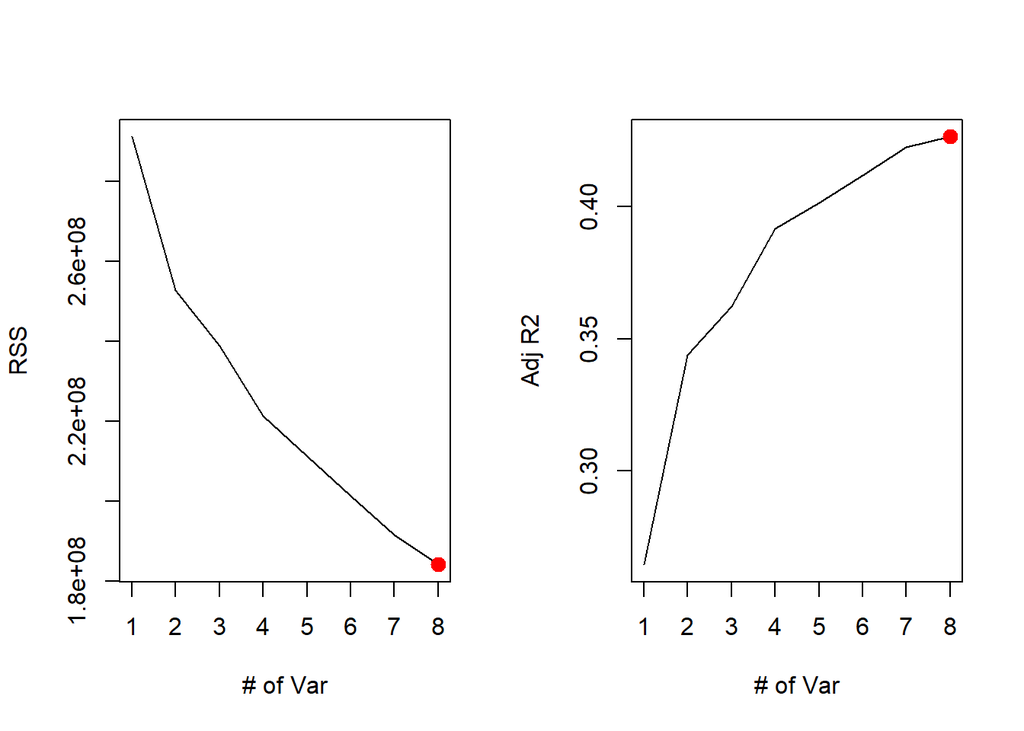

```r
points(m1,reg.summary$adjr2[m1], col="red",cex=2,pch=20)
```